# INFO 550 Project Report

Hannah Kalvin

October 19, 2020

## Introduction

This document looks at breast cancer age adjusted mortality rates in non-Hispanic women between 2003 and 2017. We specifically compare mortality rates among non-Hispanic white women and non-Hispanic Black women on the state level. In order to make the output easier to evaluate, tables and figures are grouped by region (as defined by the United States Census Bureau). Breast cancer age-adjusted mortality rates were extracted from SEER and calculated using standardized populations from the United States Census Bureau. Note that all data has been scrambled or replaced with simulated values so that this can be publicly viewed.

## Region: South

Table 1. Age adjusted breast cancer mortality rate by state and race (South)

| State | White | Black |
| --- | --- | --- |
| Alabama | 23.8 | 31.7 |
| Arkansas | 26.9 | 7.3 |
| Delaware | 26.7 | 3.6 |
| Florida | 27.6 | 24.5 |
| Georgia | 23.0 | 23.2 |
| Kentucky | 24.8 | 39.1 |
| Louisiana | 12.0 | 30.4 |
| Maryland | 11.4 | 9.7 |
| Mississippi | 23.2 | 22.5 |
| North Carolina | 6.0 | 33.6 |
| Oklahoma | 25.6 | 22.5 |
| South Carolina | 12.5 | 30.6 |
| Tennessee | 24.0 | 29.4 |
| Texas | 29.0 | 7.0 |
| Virginia | 28.6 | 12.5 |
| West Virginia | 19.2 | 14.6 |

Note:  
NA = Data not available

We see that age adjusted breast cancer mortality rates vary by race in Southern states (Table 1). These disparities are greatest in North Carolina and smallest in Georgia (shown in Table 1 and Figure 1).

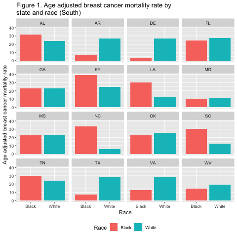

## Region: Northeast

Table 2. Age adjusted breast cancer mortality rate by state and race (Northeast)

| State | White | Black |
| --- | --- | --- |
| Connecticut | 10.1 | 14.2 |
| Maine | 23.5 | 25.3 |
| Massachusetts | 22.0 | 19.6 |
| New Hampshire | 24.0 | 23.3 |
| New Jersey | 27.1 | 34.6 |
| New York | 26.4 | 35.6 |
| Pennsylvania | 24.1 | 24.9 |
| Rhode Island | 22.9 | 12.0 |
| Vermont | 23.1 | 19.5 |

Note:  
NA = Data not available

We see that age adjusted breast cancer mortality rates vary by race in Northeastern states as well (Table 2). These disparities are greatest in Rhode Island and smallest in New Hampshire (shown in Table 2 and Figure 2).

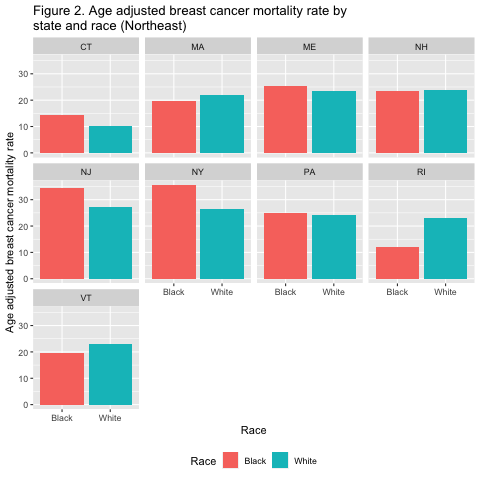

## Region: North Central

Table 3. Age adjusted breast cancer mortality rate by state and race (North Central)

| State | White | Black |
| --- | --- | --- |
| Illinois | 23.3 | 16.2 |
| Indiana | 23.9 | 9.5 |
| Iowa | 28.9 | 7.2 |
| Kansas | 27.1 | 27.9 |
| Michigan | 23.2 | 35.7 |
| Minnesota | 20.2 | 9.1 |
| Missouri | 19.7 | 26.3 |
| Nebraska | 38.0 | 27.7 |
| North Dakota | 23.2 | 16.0 |
| Ohio | 12.5 | 11.1 |
| South Dakota | 34.2 | 29.8 |
| Wisconsin | 18.8 | 12.7 |

Note:  
NA = Data not available

We see that age adjusted breast cancer mortality rates vary by race in the North Central region (Table 3). These disparities are greatest in Iowa and smallest in Kansas (shown in Table 3 and Figure 3).

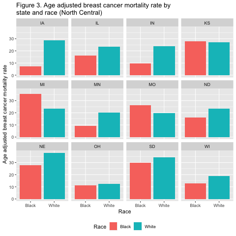

## Region: West

Table 4. Age adjusted breast cancer mortality rate by state and race (West)

| State | White | Black |
| --- | --- | --- |
| Alaska | 15.1 | 18.7 |
| Arizona | 14.8 | 31.8 |
| California | 4.5 | 26.6 |
| Colorado | 35.3 | 5.0 |
| Hawaii | 22.9 | 11.9 |
| Idaho | 6.9 | 21.6 |
| Montana | 32.0 | 11.5 |
| Nevada | 23.3 | 10.3 |
| New Mexico | 22.1 | 21.7 |
| Oregon | 23.1 | 15.9 |
| Utah | 15.0 | 26.2 |
| Washington | 13.8 | 34.2 |
| Wyoming | 10.5 | 11.1 |

Note:  
NA = Data not available

We see that age adjusted breast cancer mortality rates vary by race in the Western region as well (Table 4). These disparities are greatest in Colorado and smallest in New Mexico (shown in Table 4 and Figure 4).

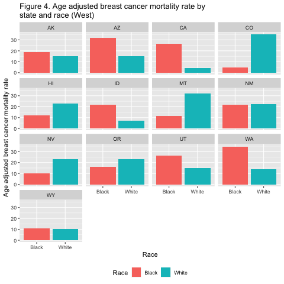